# Informe de Segmentación Demográfica

Este informe tiene como objetivo presentar una visión clara y estratégica de los distintos segmentos demográficos detectados dentro de la audiencia analizada. A partir de la información pública disponible en los perfiles sociales, se clasifican los usuarios según patrones de comportamiento, intereses, biografía, uso de emojis y análisis de sentimiento.

La segmentación obtenida permite identificar grupos clave dentro del público objetivo, facilitando la toma de decisiones para campañas de comunicación, diseño de productos y estrategias de posicionamiento. Este análisis es especialmente útil para evaluar la efectividad de una campaña en redes sociales y comprender el alcance e impacto en diferentes comunidades.

## Resumen Ejecutivo

Este informe presenta un análisis de los perfiles identificados en la campaña, clasificados por segmentos demográficos definidos según patrones de seguidores, biografía, emojis y sentimiento.

### Distribución General

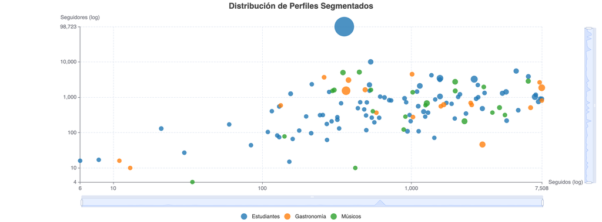

### Segmentación por Categoría

### Análisis de Sentimiento por Categoría

[figure not shown]

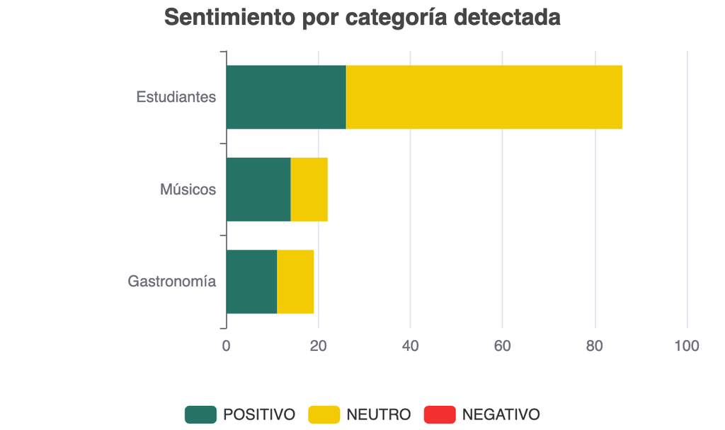

### Nube de Palabras Segmento Positivo

### Nube de Palabras Segmento Neutro

[figure not shown]

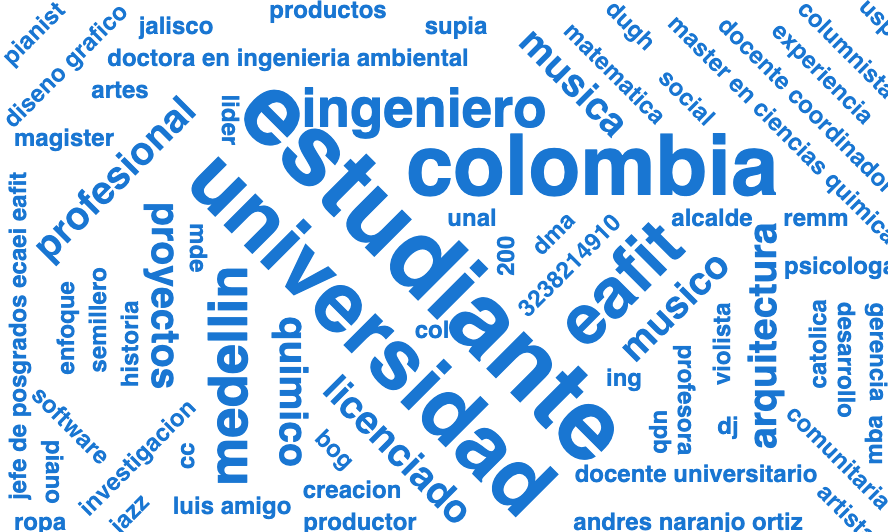

### Emojis más Utilizados por Categoría

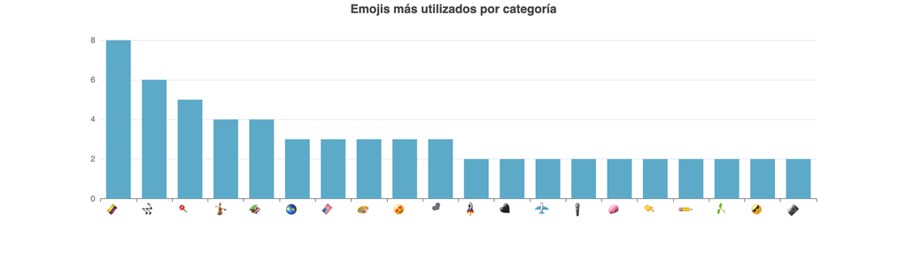

### Top Perfiles por Segmento

#### Estudiantes

**@eafit**  
Seguidores: 98.723  
Sentimiento: POSITIVO

**Bio:** Somos #EAFIT: innovación, liderazgo y acción global para la sostenibilidad del planeta y el cultivo de la humanidad. Vigilada Mineducación.  
**Palabras clave:** EAFIT, innovación, liderazgo, acción global, sostenibilidad, planeta, cultivo, humanidad, Mineducación  
**Análisis:** El texto transmite un mensaje positivo, enfocado en la innovación, liderazgo y acciones globales para la sostenibilidad y el desarrollo humano. El uso de hashtags y términos como 'innovación' y 'liderazgo' sugiere un enfoque hacia la educación superior y la responsabilidad social.

**@nodo.eafit**  
Seguidores: 9.980  
Sentimiento: POSITIVO

**Bio:** Centro de formación en tecnologías de @eafit 🚀👩🏽‍💻  
**Palabras clave:** Centro, formación, tecnologías, eafit  
**Análisis:** El texto transmite un mensaje positivo y motivador, centrado en la educación y la tecnología.

**@andresgomezbravopianista**  
Seguidores: 5.490  
Sentimiento: NEUTRO

**Bio:** Colombian pianist, professor of piano at EAFIT University. DMA from Eastman School of Music  
**Palabras clave:** Colombian, pianist, professor, piano, EAFIT University, DMA, Eastman School of Music  
**Análisis:** El texto es neutral, presentando hechos sobre la profesión y educación del individuo sin expresar emociones claramente positivas o negativas.

**@dubal**  
Seguidores: 4.176  
Sentimiento: NEUTRO

**@juanandraus**  
Seguidores: 3.843  
Sentimiento: POSITIVO

**Bio:** Músico violista | Orquesta sinfónica EAFIT | Iberacademy | universidad de Antioquia | OAcademy Cohort2025 |TECHNO 🖤 ✈️🌎🎻🇨🇴🇪🇦🇩🇪🇲🇨🇺🇸🇨🇭🇮🇹🇱🇮.  
**Palabras clave:** Músico violista, Orquesta sinfónica EAFIT, Iberacademy, universidad de Antioquia, OAcademy Cohort2025, TECHNO  
**Análisis:** El texto transmite un sentimiento positivo, reflejando pasión por la música y un estilo de vida internacional. Las palabras clave destacan la formación académica y profesional en música, así como un interés por el techno.

#### Gastronomía

**@aserjafet**  
Seguidores: 4.471  
Sentimiento: POSITIVO

**Bio:** • 👨🏽‍🍳Cocina creativa, bebidas y mucho más • 🇨🇴Soy un soñador, ven y sueña conmigo • 🍽️Creador digital - Chef en casa • Más de mí en @viveconf3  
**Palabras clave:** Cocina creativa, bebidas, soñador, Creador digital, Chef en casa  
**Análisis:** El texto transmite un sentimiento positivo, con un enfoque en la creatividad y los sueños, lo que sugiere un tono inspirador y acogedor.

**@veroweb_11**  
Seguidores: 3.657  
Sentimiento: POSITIVO

**Bio:** ⚡Community manager💻 ⚡UGC Creator | Contenido de experiencia 🎥 ⚡️Chef profesional🥗 ⚡️Mentora digital 📸 ⚡️Respaldo @veroweb11  
**Palabras clave:** Community manager, UGC Creator, Contenido de experiencia, Chef profesional, Mentora digital, Respaldo  
**Análisis:** El texto transmite un sentimiento positivo, destacando habilidades y roles profesionales con un tono enérgico y motivador.

**@bajocero.gt**  
Seguidores: 3.046  
Sentimiento: POSITIVO

**Bio:** Comida artesanal colombiana congelada🇬🇹🇨🇴 100% auténtica y gluten free 📞 3202-0010 / DM 📍 Car. a El Salvador Km 19.4, Plaza Fraijanes Express.  
**Palabras clave:** Comida artesanal, 100% auténtica, gluten free, DM, Plaza Fraijanes Express  
**Análisis:** El texto transmite un mensaje positivo, destacando la autenticidad y calidad de la comida artesanal colombiana, además de ser libre de gluten, lo cual puede atraer a un público preocupado por la salud o con restricciones alimenticias.

**@milatelocuenta**  
Seguidores: 2.623  
Sentimiento: NEUTRO

**Bio:** Bogotà comida/ lugares/ ropa/vlogs caoticos  
**Palabras clave:** Bogotà, comida, lugares, ropa, vlogs, caoticos  
**Análisis:** El texto es neutro, sin una carga emocional clara. Las palabras clave sugieren un interés en compartir contenido sobre la vida en Bogotá, incluyendo comida, lugares, moda y vlogs con un toque caótico.

**@santisosa**  
Seguidores: 1.853  
Sentimiento: POSITIVO

**Bio:** Father • fisher • sailor enthusiast • Water Sports • Amateur chef • Life is best at the lake• investor • designer• founder @agenciafeelingcompany  
**Palabras clave:** Father, fisher, sailor enthusiast, Water Sports, Amateur chef, Life is best at the lake, investor, designer, founder  
**Análisis:** El texto transmite un sentimiento positivo, destacando aspectos personales y profesionales que reflejan pasión y disfrute por la vida, especialmente en entornos acuáticos y actividades relacionadas.

#### Músicos

**@violetavidal22**  
Seguidores: 5.115  
Sentimiento: POSITIVO

**Bio:** La música es mi pasión ❤  
**Palabras clave:** música, pasión  
**Análisis:** El texto transmite un sentimiento claramente positivo, centrado en la pasión por la música.

**@saragmusical**  
Seguidores: 4.964  
Sentimiento: POSITIVO

**Bio:** 🏳️‍🌈🎻Violin Show 🎻🏳️‍🌈 🌼⚡️Música y energía para tus eventos ⚡️🌼 📍Contacto: 3216071122📲 📍Correo: saga199618@hotmail.com Colombia - Medellín 🇨🇴  
**Palabras clave:** Violin Show, Música, energía, eventos, Colombia, Medellín  
**Análisis:** El texto transmite un sentimiento positivo, enfocado en la música y la energía para eventos, con un tono alegre y vibrante.

**@santiossa1**  
Seguidores: 2.845  
Sentimiento: POSITIVO

**Bio:** 🧿 Comunicador Gráfico Publicitario (UdeM) 🎭 Consejero cultural de música (Sabaneta) 🎛 Dj selector @oss_atractor 🌀 Founder @oniryc.collective  
**Palabras clave:** Comunicador Gráfico Publicitario, Consejero cultural de música, Dj selector, Founder, oniryc.collective  
**Análisis:** El texto transmite un sentimiento positivo, reflejando pasión y dedicación en las áreas de comunicación gráfica, música y cultura. El uso de emojis creativos sugiere una personalidad artística y dinámica.

**@revistamusica**  
Seguidores: 2.731  
Sentimiento: POSITIVO

**Bio:** ¡Ahora puedes leer... lo que más te gusta escuchar! Revista especializada en música.  
**Palabras clave:** leer, gusta, escuchar, Revista, especializada, música  
**Análisis:** El texto transmite un sentimiento positivo, enfatizando la alegría y el entusiasmo por compartir contenido musical especializado.

**@albisbenavides20**  
Seguidores: 1.949  
Sentimiento: POSITIVO

**Bio:** Trabajadora Social 📄♥Amo mi Profesión Amo la música una de mis pasiones🎶cantar🎤 Ainhoa Robles Benavides mi hija🖤👩‍👧 Mi madre mi tesoro Más preciado👩  
**Palabras clave:** Trabajadora Social, Amo mi Profesión, música, pasiones, cantar, hija, madre, tesoro, preciado  
**Análisis:** El texto transmite un sentimiento abrumadoramente positivo, con un fuerte énfasis en el amor por la profesión, la música, y los lazos familiares. Las palabras clave reflejan pasión y afecto, indicando una personalidad cálida y dedicada.